# Brazilian E-Commerce Public Dataset by Olist

Welcome! This is a Brazilian ecommerce public dataset of orders made at [Olist Store](https://olist.com/pt-br/). The dataset has information of 100k orders from 2016 to 2018 made at multiple marketplaces in Brazil. Its features allows viewing an order from multiple dimensions: from order status, price, payment and freight performance to customer location, product attributes and finally reviews written by customers. We also released a geolocation dataset that relates Brazilian zip codes to lat/lng coordinates.

This is real commercial data, it has been anonymised, and references to the companies and partners in the review text have been replaced with the names of Game of Thrones great houses.

**Context**

This dataset was generously provided by Olist, the largest department store in Brazilian marketplaces. Olist connects small businesses from all over Brazil to channels without hassle and with a single contract. Those merchants are able to sell their products through the Olist Store and ship them directly to the customers using Olist logistics partners. See more on our website: www.olist.com

After a customer purchases the product from Olist Store a seller gets notified to fulfill that order. Once the customer receives the product, or the estimated delivery date is due, the customer gets a satisfaction survey by email where he can give a note for the purchase experience and write down some comments.

**Attention**

1. An order might have multiple items.
2. Each item might be fulfilled by a distinct seller.
3. All text identifying stores and partners where replaced by the names of Game of Thrones great houses.

Example of a product listing on a marketplace

[figure not shown]

**Data Schema**

The data is divided in multiple datasets for better understanding and organization. Please refer to the following data schema when working with it:

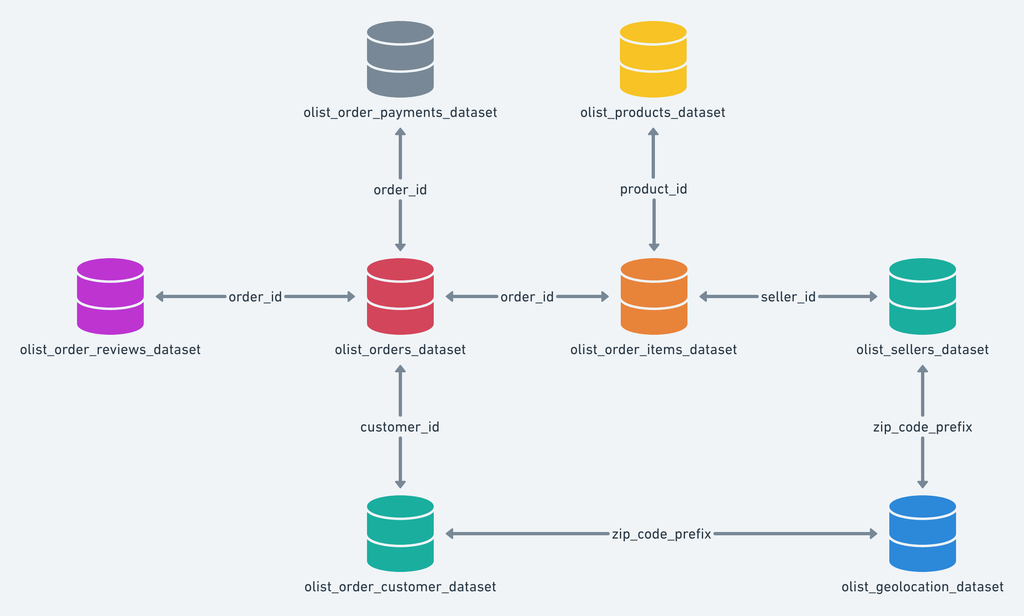

**Inspiration**

Here are some inspiration for possible outcomes from this dataset.

1. **NLP**: This dataset offers a supreme environment to parse out the reviews text through its multiple dimensions.
2. **Clustering**: Some customers didn't write a review. But why are they happy or mad?
3. **Sales Prediction**: With purchase date information you'll be able to predict future sales.
4. **Delivery Performance**: You will also be able to work through delivery performance and find ways to optimize delivery times.
5. **Product Quality**: Enjoy yourself discovering the products categories that are more prone to customer insatisfaction.
6. **Feature Engineering**: Create features from this rich dataset or attach some external public information to it.

**Acknowledgements**

Thanks to Olist for releasing this dataset.

# Objectives of this project

This project demonstrates the process of importing data to a relational database in **Postgresql**. **Olist** is a suitable data set for this purpose because it contains many tables that are relevant to each other. Moreover, their relationship is clearly given by the provider and the database can also be used for other projects. In details, the objectives include

- Establishing a schema to store table structure
- Creating many tables following a certain order so that their relationship can be maintained
- Choosing proper data types for all variables
- Setting primary and foreign keys of the tables and implementing their constraints on the tables
- Importing data to all the tables and dealing with problems arising during the importing process
- Checking schema information to validate the established structure
- Showing the Entity Relationship Diagram (ERD) to visualize the relationship among tables

The codes are prepared in Dbeaver and presented in Jupiter notebook because it is a convenient medium to include my thoughts during the importing process. Moreover, it is also a powerful tool to store the query results and present their tables. More conveniently, Python can be used to visualize the extracted data to assist the data investigation and give the user more insights.

Firstly, important Python packages are imported

```python
# manipulating data
import sqlalchemy
import pandas as pd
import warnings
import json

# Plotting and Visualization
import matplotlib.pyplot as plt
import plotly.express as px
import plotly.graph_objects as go
import plotly.io as pio
import chart_studio.plotly as py
import cufflinks as cf

# Interactive charts
from ipywidgets import interact, fixed, IntSlider
from plotly.offline import download_plotlyjs, init_notebook_mode, plot, iplot
from IPython.display import display, HTML, Image
from urllib.request import urlopen

# Options
cached_data = {}
init_notebook_mode(connected = True)
cf.go_offline()
warnings.filterwarnings(action = 'ignore')
pd.options.display.float_format = '{:,.4f}'.format
with urlopen('https://raw.githubusercontent.com/codeforamerica/click_that_hood/master/public/data/brazil-states.geojson') as response:
    Brazil = json.load(response) # Javascrip object notation
```

Next, connection to Postgresql database is established using `sqlalchemy`. A database called `olist` has been created beforehand and the connection is made directly to this database.

```python
# Setup Postgresql database connection
sqlalchemy.create_engine('postgresql://postgres:3ai6ua27hi2h@localhost:5432/olist')
%load_ext sql
%sql postgresql://postgres:3ai6ua27hi2h@localhost:5432/olist
```

Then I can interact with the database in Jupyter Notebook as naturally as in Dbeaver.

# Establish table schema

The database schema is used to store a table structure that will be made during the data importin process, a database can have many of such schemata so that it can save many different table structures

```python
%%sql
CREATE SCHEMA IF NOT EXISTS olist;
SET SCHEMA 'olist';
```

```
 * postgresql://postgres:***@localhost:5432/olist
Done.
Done.
```

```
[]
```

The schema `olist` is set as the default schema to operate with in this session. To make it convenient for re-executing the SQL codes used in this notebook, all to-be-generated tables are dropped in the reversed order that they are going to be generated, so that the re-execution will not run into any problem.

```python
%%sql
DROP TABLE IF EXISTS order_items;
DROP TABLE IF EXISTS products;
DROP TABLE IF EXISTS category_names_english;
DROP TABLE IF EXISTS order_payments;
DROP TABLE IF EXISTS order_reviews;
DROP TABLE IF EXISTS orders;
DROP TABLE IF EXISTS sellers;
DROP TABLE IF EXISTS customers;
DROP TABLE IF EXISTS geolocation;
```

```
 * postgresql://postgres:***@localhost:5432/olist
Done.
Done.
Done.
Done.
Done.
Done.
Done.
Done.
Done.
```

```
[]
```

[figure not shown]

The original data published by Olist is stored in separate csv files as presented in the picture above. There is an extra data set called `product_category_name_translation` containing all the English translations for the Brazillian terms of product categories. Other sets are similar to the structure given in the description. Next, a schema to store data structure and its tables are created to import these data sets.

# Importing data to `olist` database

Tables in a schema are connected following a certain structure. This poses a problem when importing data because if two tables are connected via a key, the key has to exist before the connection is made. Therefore, table and data have to be established and imported following a certain order. The rule is simple, tables with only primary keys are generated first, and tables with foreign keys are generated later since the primary key of a table must be established first before it can be used as the foreign key in another table. In this project, the tables are connected following the structure below

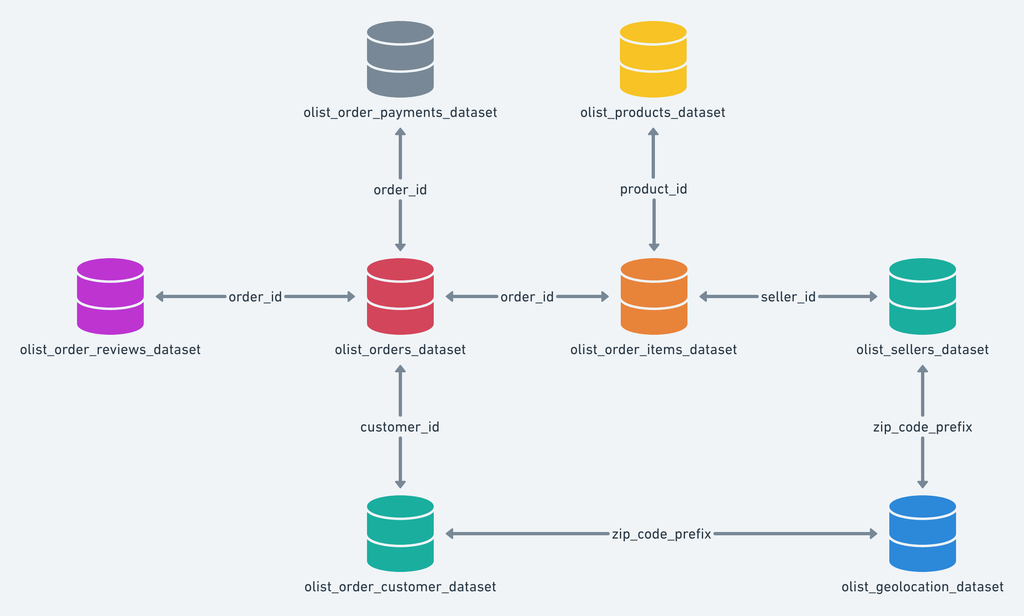

With such many tables, the complication created by these rules escalates quickly. In this project, I determine the important nodes in this network of table and import them sequentially. The importing order can be shortly summarize as

`geolocation` $\rightarrow$ `customers`/`sellers` $\rightarrow$ `orders` $\rightarrow$ `order_reviews`/`order_payments` $\rightarrow$ `category_names_english` $\rightarrow$ `products` $\rightarrow$ `order_items`

The right arrow ($\rightarrow$) indicates the order of creation while the backward slash (/) indicates either table can be created first, the order does not matter.

The intuition is quite simple, the three important nodes in this network are `geolocation`, `orders`, and `order_items` due to the connections they have:

- The table `geolocation` does not have any foreign key but it is connected to two other tables via its primary key `zip_code_prefix`, so it is created first
- The table `orders` only has one foreign key and connect to three other tables using its primary key, so it has to be created first for other tables to be created
- The table `order_items` does not have a primary key and only contains foreign keys, so it is created last

## Create table `geolocation`

The table `geolocation` is important for the first node, so it is created first.

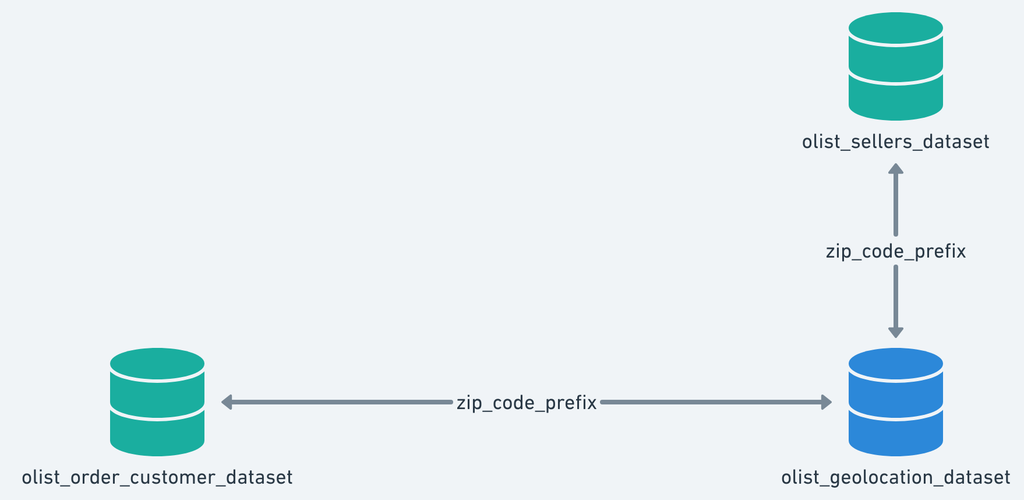

```python
%%sql
DROP TABLE IF EXISTS geolocation;
CREATE TABLE IF NOT EXISTS geolocation (
	zip_code_prefix INTEGER NOT NULL,
	latitude NUMERIC,
	longitude NUMERIC,
	city TEXT,
	state TEXT
);
COPY geolocation FROM 'E:/Data/Olist/olist_geolocation_dataset.csv' HEADER CSV DELIMITER ',';
SELECT * FROM geolocation ORDER BY zip_code_prefix LIMIT 10;
```

```
 * postgresql://postgres:***@localhost:5432/olist
Done.
Done.
1000163 rows affected.
10 rows affected.
```

| zip_code_prefix | latitude | longitude | city | state |
| --- | --- | --- | --- | --- |
| 1001 | -23.549779299469115 | -46.6339571183853 | são paulo | SP |
| 1001 | -23.551336655288804 | -46.63402699777831 | sao paulo | SP |
| 1001 | -23.550497706907514 | -46.63433817805407 | sao paulo | SP |
| 1001 | -23.551336655288804 | -46.63402699777831 | sao paulo | SP |
| 1001 | -23.54929199999999 | -46.633559478233785 | sao paulo | SP |
| 1001 | -23.55064182209015 | -46.634409790322515 | sao paulo | SP |
| 1001 | -23.551426655288804 | -46.63407394670785 | sao paulo | SP |
| 1001 | -23.54969829946912 | -46.63390859285005 | sao paulo | SP |
| 1001 | -23.550497706907514 | -46.63433817805407 | sao paulo | SP |
| 1001 | -23.550497706907514 | -46.63433817805407 | sao paulo | SP |

It should be the case that `zip_code_prefix` is used as the primary key for this table, but `zip_code_prefix` of the given set has duplicate values (as shown in the query result) for the same zip code prefix, so it cannot be set as the primary key. This might be caused by the manipulations of the publisher to protect their user privacy. For this reason, it will not be connected to other tables since it will cause dupplications when joining with other tables.

Next, two other tables are created but the column `zip_code_prefix` will not be set as foreign key for the reason discussed above.

## Create table `customers`

With this table, `customer_id` is set as the primary key as it is used to connect with other tables as shown in the given diagram.

```python
%%sql
DROP TABLE IF EXISTS customers;
CREATE TABLE IF NOT EXISTS customers (
	customer_id TEXT PRIMARY KEY NOT NULL,
	customer_unique_id TEXT,
	zip_code_prefix INTEGER NOT NULL,
	city TEXT,
	state TEXT
);
COPY customers FROM 'E:/Data/Olist/olist_customers_dataset.csv' HEADER CSV DELIMITER ',';
SELECT * FROM customers LIMIT 10;
```

```
 * postgresql://postgres:***@localhost:5432/olist
Done.
Done.
99441 rows affected.
10 rows affected.
```

| customer_id | customer_unique_id | zip_code_prefix | city | state |
| --- | --- | --- | --- | --- |
| 06b8999e2fba1a1fbc88172c00ba8bc7 | 861eff4711a542e4b93843c6dd7febb0 | 14409 | franca | SP |
| 18955e83d337fd6b2def6b18a428ac77 | 290c77bc529b7ac935b93aa66c333dc3 | 9790 | sao bernardo do campo | SP |
| 4e7b3e00288586ebd08712fdd0374a03 | 060e732b5b29e8181a18229c7b0b2b5e | 1151 | sao paulo | SP |
| b2b6027bc5c5109e529d4dc6358b12c3 | 259dac757896d24d7702b9acbbff3f3c | 8775 | mogi das cruzes | SP |
| 4f2d8ab171c80ec8364f7c12e35b23ad | 345ecd01c38d18a9036ed96c73b8d066 | 13056 | campinas | SP |
| 879864dab9bc3047522c92c82e1212b8 | 4c93744516667ad3b8f1fb645a3116a4 | 89254 | jaragua do sul | SC |
| fd826e7cf63160e536e0908c76c3f441 | addec96d2e059c80c30fe6871d30d177 | 4534 | sao paulo | SP |
| 5e274e7a0c3809e14aba7ad5aae0d407 | 57b2a98a409812fe9618067b6b8ebe4f | 35182 | timoteo | MG |
| 5adf08e34b2e993982a47070956c5c65 | 1175e95fb47ddff9de6b2b06188f7e0d | 81560 | curitiba | PR |
| 4b7139f34592b3a31687243a302fa75b | 9afe194fb833f79e300e37e580171f22 | 30575 | belo horizonte | MG |

## Creating table `sellers`

Similarly, the table `sellers` is created with `seller_id` as the primary key as it uses this key to connect to the table `order_items`.

```python
%%sql
DROP TABLE IF EXISTS sellers;
CREATE TABLE IF NOT EXISTS sellers (
	seller_id TEXT PRIMARY KEY NOT NULL,
	zip_code_prefix INTEGER,
	city TEXT,
	state TEXT
);
COPY sellers FROM 'E:/Data/Olist/olist_sellers_dataset.csv' HEADER CSV DELIMITER ',';
SELECT * FROM sellers LIMIT 10;
```

```
 * postgresql://postgres:***@localhost:5432/olist
Done.
Done.
3095 rows affected.
10 rows affected.
```

| seller_id | zip_code_prefix | city | state |
| --- | --- | --- | --- |
| 3442f8959a84dea7ee197c632cb2df15 | 13023 | campinas | SP |
| d1b65fc7debc3361ea86b5f14c68d2e2 | 13844 | mogi guacu | SP |
| ce3ad9de960102d0677a81f5d0bb7b2d | 20031 | rio de janeiro | RJ |
| c0f3eea2e14555b6faeea3dd58c1b1c3 | 4195 | sao paulo | SP |
| 51a04a8a6bdcb23deccc82b0b80742cf | 12914 | braganca paulista | SP |
| c240c4061717ac1806ae6ee72be3533b | 20920 | rio de janeiro | RJ |
| e49c26c3edfa46d227d5121a6b6e4d37 | 55325 | brejao | PE |
| 1b938a7ec6ac5061a66a3766e0e75f90 | 16304 | penapolis | SP |
| 768a86e36ad6aae3d03ee3c6433d61df | 1529 | sao paulo | SP |
| ccc4bbb5f32a6ab2b7066a4130f114e3 | 80310 | curitiba | PR |

## Creating table `orders`

The table `orders` is the next important node in the network. Its primary key is used to connect to three other tables, while the foreign key it needs to connect to the table `customers` is already available. Hence, it is created first so that the other tables can be created.

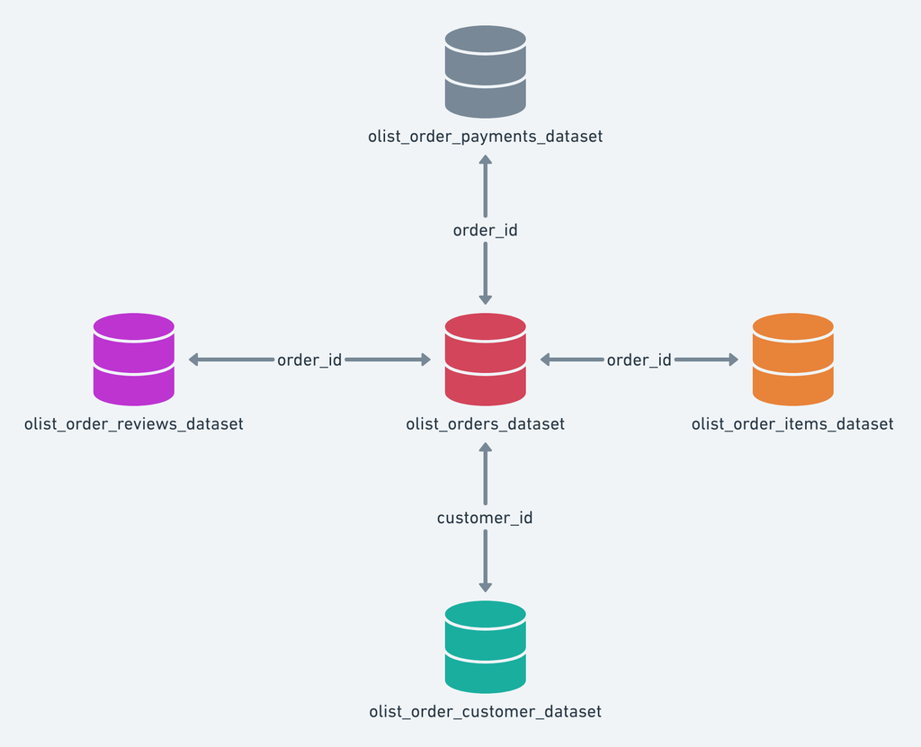

```python
%%sql
DROP TABLE IF EXISTS orders;
CREATE TABLE IF NOT EXISTS orders (
	order_id TEXT PRIMARY KEY NOT NULL,
	customer_id TEXT NOT NULL,
	status TEXT,
	purchase_timestamp TIMESTAMP,
	approval_timestamp TIMESTAMP,
	delivered_carrier_date TIMESTAMP,
	delivered_customer_date TIMESTAMP,
	estimated_delivery_date TIMESTAMP,
	CONSTRAINT fk_customer FOREIGN KEY (customer_id) REFERENCES customers(customer_id)
);
COPY orders FROM 'E:/Data/Olist/olist_orders_dataset.csv' HEADER CSV DELIMITER ',';
SELECT * FROM orders ORDER BY purchase_timestamp LIMIT 10;
```

```
 * postgresql://postgres:***@localhost:5432/olist
Done.
Done.
99441 rows affected.
10 rows affected.
```

| order_id | customer_id | status | purchase_timestamp | approval_timestamp | delivered_carrier_date | delivered_customer_date | estimated_delivery_date |
| --- | --- | --- | --- | --- | --- | --- | --- |
| 2e7a8482f6fb09756ca50c10d7bfc047 | 08c5351a6aca1c1589a38f244edeee9d | shipped | 2016-09-04 21:15:19 | 2016-10-07 13:18:03 | 2016-10-18 13:14:51 | None | 2016-10-20 00:00:00 |
| e5fa5a7210941f7d56d0208e4e071d35 | 683c54fc24d40ee9f8a6fc179fd9856c | canceled | 2016-09-05 00:15:34 | 2016-10-07 13:17:15 | None | None | 2016-10-28 00:00:00 |
| 809a282bbd5dbcabb6f2f724fca862ec | 622e13439d6b5a0b486c435618b2679e | canceled | 2016-09-13 15:24:19 | 2016-10-07 13:16:46 | None | None | 2016-09-30 00:00:00 |
| bfbd0f9bdef84302105ad712db648a6c | 86dc2ffce2dfff336de2f386a786e574 | delivered | 2016-09-15 12:16:38 | 2016-09-15 12:16:38 | 2016-11-07 17:11:53 | 2016-11-09 07:47:38 | 2016-10-04 00:00:00 |
| 71303d7e93b399f5bcd537d124c0bcfa | b106b360fe2ef8849fbbd056f777b4d5 | canceled | 2016-10-02 22:07:52 | 2016-10-06 15:50:56 | None | None | 2016-10-25 00:00:00 |
| 3b697a20d9e427646d92567910af6d57 | 355077684019f7f60a031656bd7262b8 | delivered | 2016-10-03 09:44:50 | 2016-10-06 15:50:54 | 2016-10-23 14:02:13 | 2016-10-26 14:02:13 | 2016-10-27 00:00:00 |
| be5bc2f0da14d8071e2d45451ad119d9 | 7ec40b22510fdbea1b08921dd39e63d8 | delivered | 2016-10-03 16:56:50 | 2016-10-06 16:03:44 | 2016-10-21 16:33:46 | 2016-10-27 18:19:38 | 2016-11-07 00:00:00 |
| 65d1e226dfaeb8cdc42f665422522d14 | 70fc57eeae292675927697fe03ad3ff5 | canceled | 2016-10-03 21:01:41 | 2016-10-04 10:18:57 | 2016-10-25 12:14:28 | 2016-11-08 10:58:34 | 2016-11-25 00:00:00 |
| a41c8759fbe7aab36ea07e038b2d4465 | 6f989332712d3222b6571b1cf5b835ce | delivered | 2016-10-03 21:13:36 | 2016-10-05 03:11:49 | 2016-10-25 11:57:59 | 2016-11-03 10:58:07 | 2016-11-29 00:00:00 |
| d207cc272675637bfed0062edffd0818 | b8cf418e97ae795672d326288dfab7a7 | delivered | 2016-10-03 22:06:03 | 2016-10-04 10:28:07 | 2016-10-21 14:23:37 | 2016-10-31 11:07:42 | 2016-11-23 00:00:00 |

The next tables `order_reviews` and `order_payments` can be created interchangeably because they only need `order_id` as the foreign key and do not need to have a primary key.

## Creating table `order_reviews`

The structure of the query is similar except for the additional constraint that assigns the column `order_id` as the foreign key

```python
%%sql
DROP TABLE IF EXISTS order_reviews;
CREATE TABLE IF NOT EXISTS order_reviews (
	review_id TEXT NOT NULL,
	order_id TEXT NOT NULL,
	rating INTEGER,
	review_title TEXT,
	review_content TEXT,
	creation_timestamp TIMESTAMP,
	answer_timestamp TIMESTAMP,
	CONSTRAINT fk_reviews FOREIGN KEY (order_id) REFERENCES orders(order_id)
);
COPY order_reviews FROM 'E:/Data/Olist/olist_order_reviews_dataset.csv' HEADER CSV DELIMITER ',';
SELECT * FROM order_reviews ORDER BY creation_timestamp LIMIT 10;
```

```
 * postgresql://postgres:***@localhost:5432/olist
Done.
Done.
99224 rows affected.
10 rows affected.
```

| review_id | order_id | rating | review_title | review_content | creation_timestamp | answer_timestamp |
| --- | --- | --- | --- | --- | --- | --- |
| 69ac6a27fde9855ebeaaecac0f78058b | 809a282bbd5dbcabb6f2f724fca862ec | 1 | None | MEU PEDIDO NÃO FOI ENTREGUE E NÃO FOI DADA NENHUMA SATISTAÇÃO | 2016-10-02 00:00:00 | 2016-10-26 12:31:00 |
| 6916ca4502d6d3bfd39818759d55d536 | bfbd0f9bdef84302105ad712db648a6c | 1 | None | nao recebi o produto e nem resposta da empresa | 2016-10-06 00:00:00 | 2016-10-07 18:32:28 |
| 49f695dffa457eaba90d388a5c37e942 | e5215415bb6f76fe3b7cb68103a0d1c0 | 1 | None | PRODUTO NÃO CHEGOU,E JÁ PASSOU O PRAZO DE ENTREGA | 2016-10-09 00:00:00 | 2016-10-11 14:31:29 |
| b2d5d8db2a841d27a72e4c06c6212368 | 9aa3197e4887919fde0307fc23601d7a | 4 | None | Só chegou uma parte do pedido ate agora.. | 2016-10-15 00:00:00 | 2016-10-17 21:02:49 |
| 743d98b1a4782f0646898fc915ef002a | e2144124f98f3bf46939bc5183104041 | 4 | None | None | 2016-10-15 00:00:00 | 2016-10-16 03:20:17 |
| 53752edb26544dd41c1209f582c9c589 | b8b9d7046c083150cb5360b83a8ebb51 | 5 | None | O pedido foi entregue antes do prazo pr0metido | 2016-10-16 01:00:00 | 2016-10-16 15:45:11 |
| 5d76a01a07627d6eab445af668ac3aef | 67418605ab8f9414a2e238bbcdde1312 | 5 | None | Muito TOP o produto. Lampadas de ótima qualidade, que iluminam muito bem e consomem quase nada. | 2016-10-18 00:00:00 | 2016-12-26 15:24:14 |
| da520c13fbd4886bc0c1207df180106c | d3a84031db6c5de813d5a3a3489712ca | 5 | None | None | 2016-10-18 00:00:00 | 2016-10-19 21:21:25 |
| 8e8cc3353ea9bd13e1450d8fa269d474 | ed3d575bd3358123b063ee64cdecdef5 | 5 | None | Chego dentro do prazo tudo bem embalado | 2016-10-18 00:00:00 | 2016-10-18 20:29:05 |
| b2fc2fac36fdef519925b2f55a95d8e4 | 85841af0d94e5d0cd3a9c0e42e565b74 | 5 | None | None | 2016-10-18 00:00:00 | 2016-12-06 20:48:13 |

## Creating table `order_payments`

`order_payments` also uses `order_id` as the foreign key to connect to the table `orders`, so an additional constraint is also added to the query.

```python
%%sql
DROP TABLE IF EXISTS order_payments;
CREATE TABLE IF NOT EXISTS order_payments (
	order_id TEXT NOT NULL,
	payment_sequential INTEGER,
	payment_type TEXT,
	payment_installments INTEGER,
	payment_value NUMERIC,
	CONSTRAINT fk_payments FOREIGN KEY (order_id) REFERENCES orders(order_id)
);
COPY order_payments FROM 'E:/Data/Olist/olist_order_payments_dataset.csv' HEADER CSV DELIMITER ',';
SELECT * FROM order_payments LIMIT 10;
```

```
 * postgresql://postgres:***@localhost:5432/olist
Done.
Done.
103886 rows affected.
10 rows affected.
```

| order_id | payment_sequential | payment_type | payment_installments | payment_value |
| --- | --- | --- | --- | --- |
| b81ef226f3fe1789b1e8b2acac839d17 | 1 | credit_card | 8 | 99.33 |
| a9810da82917af2d9aefd1278f1dcfa0 | 1 | credit_card | 1 | 24.39 |
| 25e8ea4e93396b6fa0d3dd708e76c1bd | 1 | credit_card | 1 | 65.71 |
| ba78997921bbcdc1373bb41e913ab953 | 1 | credit_card | 8 | 107.78 |
| 42fdf880ba16b47b59251dd489d4441a | 1 | credit_card | 2 | 128.45 |
| 298fcdf1f73eb413e4d26d01b25bc1cd | 1 | credit_card | 2 | 96.12 |
| 771ee386b001f06208a7419e4fc1bbd7 | 1 | credit_card | 1 | 81.16 |
| 3d7239c394a212faae122962df514ac7 | 1 | credit_card | 3 | 51.84 |
| 1f78449c87a54faf9e96e88ba1491fa9 | 1 | credit_card | 6 | 341.09 |
| 0573b5e23cbd798006520e1d5b4c6714 | 1 | boleto | 1 | 51.95 |

## Creating table `category_names_english`

`category_names_english` is an additional table that the publisher added to the data set to help the user with the translation of the category names. It connects to the table `products` using the primary key `product_category`. The original set does not provide enough translations so when the table `products` is created later, it cannot use `product_category` as the reference for the foreign key. The workaround is that the missing entries are added to the csv file mannually. The details are given below

[figure not shown]

```python
%%sql
DROP TABLE IF EXISTS category_names_english;
CREATE TABLE IF NOT EXISTS category_names_english (
	product_category TEXT PRIMARY KEY NOT NULL,
	product_category_eng TEXT
);
COPY category_names_english FROM 'E:/Data/Olist/product_category_name_translation.csv' HEADER CSV DELIMITER ',';
SELECT * FROM category_names_english LIMIT 10;
```

```
 * postgresql://postgres:***@localhost:5432/olist
Done.
Done.
73 rows affected.
10 rows affected.
```

| product_category | product_category_eng |
| --- | --- |
| portateis_cozinha_e_preparadores_de_alimentos | kitchen_and_food_preparadores_portables |
| pc_gamer | pc_gamer |
| beleza_saude | health_beauty |
| informatica_acessorios | computers_accessories |
| automotivo | auto |
| cama_mesa_banho | bed_bath_table |
| moveis_decoracao | furniture_decor |
| esporte_lazer | sports_leisure |
| perfumaria | perfumery |
| utilidades_domesticas | housewares |

The original data does not contain English name for the category `pc_gamer`, `portateis_cozinha_e_preparadores_de_alimentos` manual additions are needed

[figure not shown]

## Create table `products`

With the table `category_names_english` available, the table `products` can be created. This table has `product_id` as the primary key and use `product_category` as the foreign key to connect to the table `category_names_english`

```python
%%sql
DROP TABLE IF EXISTS products;
CREATE TABLE IF NOT EXISTS products (
	product_id TEXT PRIMARY KEY NOT NULL,
	product_category TEXT,
	name_length INTEGER,
	description_length INTEGER,
	photos_quantity INTEGER,
	weight_g INTEGER,
	length_cm INTEGER,
	height_cm INTEGER,
	width_cm INTEGER,
	CONSTRAINT fk_cateogry_eng FOREIGN KEY (product_category) REFERENCES category_names_english(product_category)
);
COPY products FROM 'E:/Data/Olist/olist_products_dataset.csv' HEADER CSV DELIMITER ',';
SELECT * FROM products LIMIT 10;
```

```
 * postgresql://postgres:***@localhost:5432/olist
Done.
Done.
32951 rows affected.
10 rows affected.
```

| product_id | product_category | name_length | description_length | photos_quantity | weight_g | length_cm | height_cm | width_cm |
| --- | --- | --- | --- | --- | --- | --- | --- | --- |
| 1e9e8ef04dbcff4541ed26657ea517e5 | perfumaria | 40 | 287 | 1 | 225 | 16 | 10 | 14 |
| 3aa071139cb16b67ca9e5dea641aaa2f | artes | 44 | 276 | 1 | 1000 | 30 | 18 | 20 |
| 96bd76ec8810374ed1b65e291975717f | esporte_lazer | 46 | 250 | 1 | 154 | 18 | 9 | 15 |
| cef67bcfe19066a932b7673e239eb23d | bebes | 27 | 261 | 1 | 371 | 26 | 4 | 26 |
| 9dc1a7de274444849c219cff195d0b71 | utilidades_domesticas | 37 | 402 | 4 | 625 | 20 | 17 | 13 |
| 41d3672d4792049fa1779bb35283ed13 | instrumentos_musicais | 60 | 745 | 1 | 200 | 38 | 5 | 11 |
| 732bd381ad09e530fe0a5f457d81becb | cool_stuff | 56 | 1272 | 4 | 18350 | 70 | 24 | 44 |
| 2548af3e6e77a690cf3eb6368e9ab61e | moveis_decoracao | 56 | 184 | 2 | 900 | 40 | 8 | 40 |
| 37cc742be07708b53a98702e77a21a02 | eletrodomesticos | 57 | 163 | 1 | 400 | 27 | 13 | 17 |
| 8c92109888e8cdf9d66dc7e463025574 | brinquedos | 36 | 1156 | 1 | 600 | 17 | 10 | 12 |

Then the last table `order_items` can be created.

## Create table `order_items`

The table `order_items` does not have a primary key, but it is connected to three other tables by three different foreign keys. This is the reason why it has to be the last table to be created because it needs these foreign keys to be established beforehand.

```python
%%sql
DROP TABLE IF EXISTS order_items;
CREATE TABLE IF NOT EXISTS order_items (
	order_id TEXT NOT NULL,
	item_id TEXT,
	product_id TEXT NOT NULL,
	seller_id TEXT NOT NULL,
	shipping_limit_date TIMESTAMP,
	price NUMERIC,
	freight_value NUMERIC,
	CONSTRAINT fk_products FOREIGN KEY (product_id) REFERENCES products(product_id),
	CONSTRAINT fk_orders FOREIGN KEY (order_id) REFERENCES orders(order_id),
	CONSTRAINT fk_sellers FOREIGN KEY (seller_id) REFERENCES sellers(seller_id)
);
COPY order_items FROM 'E:/Data/Olist/olist_order_items_dataset.csv' HEADER CSV DELIMITER ',';
SELECT * FROM order_items LIMIT 10;
```

```
 * postgresql://postgres:***@localhost:5432/olist
Done.
Done.
112650 rows affected.
10 rows affected.
```

| order_id | item_id | product_id | seller_id | shipping_limit_date | price | freight_value |
| --- | --- | --- | --- | --- | --- | --- |
| 00010242fe8c5a6d1ba2dd792cb16214 | 1 | 4244733e06e7ecb4970a6e2683c13e61 | 48436dade18ac8b2bce089ec2a041202 | 2017-09-19 09:45:35 | 58.90 | 13.29 |
| 00018f77f2f0320c557190d7a144bdd3 | 1 | e5f2d52b802189ee658865ca93d83a8f | dd7ddc04e1b6c2c614352b383efe2d36 | 2017-05-03 11:05:13 | 239.90 | 19.93 |
| 000229ec398224ef6ca0657da4fc703e | 1 | c777355d18b72b67abbeef9df44fd0fd | 5b51032eddd242adc84c38acab88f23d | 2018-01-18 14:48:30 | 199.00 | 17.87 |
| 00024acbcdf0a6daa1e931b038114c75 | 1 | 7634da152a4610f1595efa32f14722fc | 9d7a1d34a5052409006425275ba1c2b4 | 2018-08-15 10:10:18 | 12.99 | 12.79 |
| 00042b26cf59d7ce69dfabb4e55b4fd9 | 1 | ac6c3623068f30de03045865e4e10089 | df560393f3a51e74553ab94004ba5c87 | 2017-02-13 13:57:51 | 199.90 | 18.14 |
| 00048cc3ae777c65dbb7d2a0634bc1ea | 1 | ef92defde845ab8450f9d70c526ef70f | 6426d21aca402a131fc0a5d0960a3c90 | 2017-05-23 03:55:27 | 21.90 | 12.69 |
| 00054e8431b9d7675808bcb819fb4a32 | 1 | 8d4f2bb7e93e6710a28f34fa83ee7d28 | 7040e82f899a04d1b434b795a43b4617 | 2017-12-14 12:10:31 | 19.90 | 11.85 |
| 000576fe39319847cbb9d288c5617fa6 | 1 | 557d850972a7d6f792fd18ae1400d9b6 | 5996cddab893a4652a15592fb58ab8db | 2018-07-10 12:30:45 | 810.00 | 70.75 |
| 0005a1a1728c9d785b8e2b08b904576c | 1 | 310ae3c140ff94b03219ad0adc3c778f | a416b6a846a11724393025641d4edd5e | 2018-03-26 18:31:29 | 145.95 | 11.65 |
| 0005f50442cb953dcd1d21e1fb923495 | 1 | 4535b0e1091c278dfd193e5a1d63b39f | ba143b05f0110f0dc71ad71b4466ce92 | 2018-07-06 14:10:56 | 53.99 | 11.40 |

# Checking schema information

To check for whether the tables are properly created, we can look at the `olist` schema of the `information_schema.tables`.

```python
%%sql
SELECT * FROM information_schema.tables WHERE table_schema = 'olist';
```

```
 * postgresql://postgres:***@localhost:5432/olist
9 rows affected.
```

| table_catalog | table_schema | table_name | table_type | self_referencing_column_name | reference_generation | user_defined_type_catalog | user_defined_type_schema | user_defined_type_name | is_insertable_into | is_typed | commit_action |
| --- | --- | --- | --- | --- | --- | --- | --- | --- | --- | --- | --- |
| olist | olist | geolocation | BASE TABLE | None | None | None | None | None | YES | NO | None |
| olist | olist | customers | BASE TABLE | None | None | None | None | None | YES | NO | None |
| olist | olist | orders | BASE TABLE | None | None | None | None | None | YES | NO | None |
| olist | olist | category_names_english | BASE TABLE | None | None | None | None | None | YES | NO | None |
| olist | olist | order_reviews | BASE TABLE | None | None | None | None | None | YES | NO | None |
| olist | olist | products | BASE TABLE | None | None | None | None | None | YES | NO | None |
| olist | olist | order_payments | BASE TABLE | None | None | None | None | None | YES | NO | None |
| olist | olist | order_items | BASE TABLE | None | None | None | None | None | YES | NO | None |
| olist | olist | sellers | BASE TABLE | None | None | None | None | None | YES | NO | None |

The table shows that all the needed tables are generated properly and ready for investigation.

# Entity Relationship Diagram

Entity Relationship Diagram of a schema presents the data structure by showing how the tables are connected visually. With such an ERD, we can check visually whether the created data structure is able to replicate the original structure.

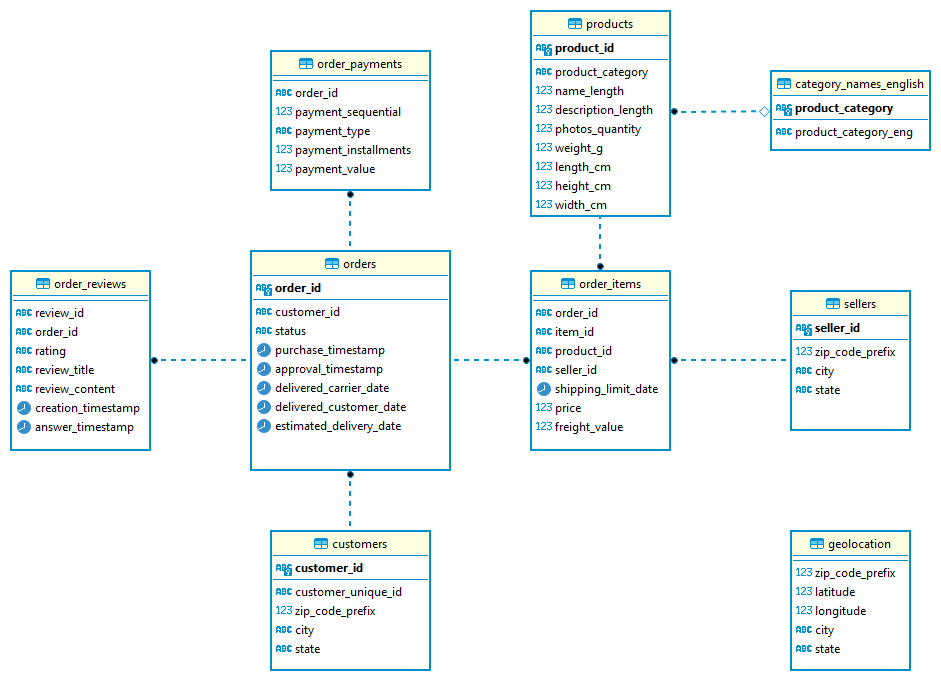

The ERD does not show the connections of the table `geolocation` with two tables `customers` and `sellers` due to the problem with given data mentioned above. It also shows an additional table `category_name_english` as this is the additional data set used for the translation of product category names from Brazillian to English. The primary keys of these tables are also highlighted in the diagram and the data type is also given.

# Executive summary

The data is now ready to be extracted and manipulated using SQL queries. The next steps might be exploratory analysis and data visualization so that more insights can be gained for further investigations.